# EBS_similarity_heatmap_distance

```r
library(data.table)
library(viridis)
library(ggplot2)
library(reshape2)
library(geosphere)
library(vegan)
library(raster)
library(here)
library(cowplot)
library(plyr)

#load data
dat_EBS_grid.reduced_3plustows <- readRDS("/Users/zoekitchel/Documents/grad school/Rutgers/Repositories/trawl_spatial_turnover/data/gridded/USA-EBS/grid_EBS.reduced_3plustows.rds")

#distance among grid cells

ebs_reg_distances.l <- readRDS("/Users/zoekitchel/Documents/grad school/Rutgers/Repositories/trawl_spatial_turnover/data/gridded/USA-EBS/ebs_reg_distances.l.rds")
```

Region Stats

- Number of species in region
- Length of study period
- Number of years in which data was collected
- Range of latitudes sampled
- Mid latitude of region
- Range of longitudes sampled
- Overall area sampled
- Depths sampled

```r
ebs_stats <- data.table(region = character() , season = character(), spp_num = numeric(), study_period = numeric(), study_duration = numeric(), lat_range = numeric(), mid_lat = numeric(), lon_range = numeric(), area = numeric(), depth_range = numeric(),  mid_depth = numeric())


#maps
####unique lat lon
ebs_lat_lon <- unique(dat_EBS_grid.reduced_3plustows[,.(latitude, longitude)])

ebs_pts <- st_as_sf(ebs_lat_lon, coords=c('longitude','latitude'), crs=4326 )

ebs_conc <- concaveman(ebs_pts)

ebs_area <- st_area(ebs_conc) #m2

#row
ebs <- c("ebs","NA",length(unique(dat_EBS_grid.reduced_3plustows$accepted_name)),
               max(dat_EBS_grid.reduced_3plustows$year)-min(dat_EBS_grid.reduced_3plustows$year),
               length(unique(dat_EBS_grid.reduced_3plustows$year)),
               max(dat_EBS_grid.reduced_3plustows$latitude)-min(dat_EBS_grid.reduced_3plustows$latitude),
               mean(dat_EBS_grid.reduced_3plustows$latitude),
               max(dat_EBS_grid.reduced_3plustows$longitude)-min(dat_EBS_grid.reduced_3plustows$longitude),
               ebs_area,
               max(dat_EBS_grid.reduced_3plustows$depth, na.rm = T)-min(dat_EBS_grid.reduced_3plustows$depth, na.rm = T),
               mean(dat_EBS_grid.reduced_3plustows$depth, na.rm = T)
               )



ebs_stats <- data.table(rbind(ebs))

colnames(ebs_stats)<-c("region","season","spp_num","study_period","study_duration","lat_range","mid_lat","lon_range","area","depth_range","mid_depth")
```

Lists of Years

```r
dat_EBS_grid.reduced_3plustows[,year:= as.numeric(year)] #make numeric
setorder(dat_EBS_grid.reduced_3plustows, year)

ebs_years <- unique(dat_EBS_grid.reduced_3plustows[,year])
```

Haul ID keys

```r
ebs_haul_ids <- unique(dat_EBS_grid.reduced_3plustows[,haul_id])
ebs_haul_ids_key <- data.table(haul_id = ebs_haul_ids, key_ID = seq(1,length(ebs_haul_ids), by = 1))
```

Convert haul_ids to numeric key_IDs

```r
dat_EBS_grid.reduced_3plustows <- dat_EBS_grid.reduced_3plustows[ebs_haul_ids_key, on = "haul_id"]
```

Dissimilarities across multiple years

```r
library(betapart)
ebs_distances_dissimilarities_allyears <- data.table("haul_id1" = integer(), "haul_id2" = integer(), "distance" = numeric(),"bray_curtis_dissimilarity_balanced" = numeric(), year = integer(), "jaccard_dissimilarity_turnover" = numeric())

#Now loop through all years
for (i in 1:length(ebs_years)) {
  reduced_year <- dat_EBS_grid.reduced_3plustows[year == ebs_years[i],]

#cannot have wgt or num
  reduced_year <- reduced_year[!is.na(wgt_cpue),]

  #distances among cells
  setorder(reduced_year, key_ID)

  latitude_longitude_haul_id <- unique(reduced_year[,.(latitude,longitude,key_ID)])
  ebs_distances <- distm(latitude_longitude_haul_id[,.(longitude,latitude)])
  key_IDs <- latitude_longitude_haul_id[,key_ID]

  colnames(ebs_distances) <- rownames(ebs_distances) <- key_IDs

  #wide to longitudeg
  haul_id_distances.l <- reshape2::melt(ebs_distances,varnames = (c("haul_id1", "haul_id2")), value.name = "distance")

  #make into data table
  haul_id_distances.l <- data.table(haul_id_distances.l)


  reduced_year_wide <- dcast(reduced_year, key_ID + year ~ accepted_name, value.var = "wgt_cpue", fun.aggregate = sum) #longitude to wide data for community matrix, column names are cell then species


  ncols <- ncol(reduced_year_wide)
  communitymatrix <- reduced_year_wide[,3:ncols] #community matrix with year and cell on far right
  communitymatrix.occurence <- communitymatrix
  communitymatrix.occurence[communitymatrix.occurence > 0] <- 1

  #list of haul_id keys
  key_IDs_subset <- reduced_year_wide$key_ID

  dissimilarities_abundance <- beta.pair.abund(communitymatrix, index.family = "bray") #dissimilarity
  dissimilarities_occurrence <- beta.pair(communitymatrix.occurence, index.family = "jaccard") #dissimilarity

  #make into matrix
  dissimilarities_abundance.m <- as.matrix(dissimilarities_abundance$beta.bray.bal, labels=TRUE) #bal = balanced
  dissimilarities_occurrence.m <- as.matrix(dissimilarities_occurrence$beta.jtu, labels=TRUE) #jtu = turnover
  colnames(dissimilarities_abundance.m) <- rownames(dissimilarities_abundance.m) <- key_IDs_subset
  colnames(dissimilarities_occurrence.m) <- rownames(dissimilarities_occurrence.m) <- key_IDs_subset

  #reshape dissimilarities
  dissimilarities_abundance.l <- reshape2::melt(dissimilarities_abundance.m, varnames = c("haul_id1", "haul_id2"), value.name = "bray_curtis_dissimilarity_balanced")
  dissimilarities_occurrence.l <- reshape2::melt(dissimilarities_occurrence.m, varnames = c("haul_id1", "haul_id2"), value.name = "jaccard_dissimilarity_turnover")
  dissimilarities_abundance.l <- data.table(dissimilarities_abundance.l) #and then to data table
  dissimilarities_occurrence.l <- data.table(dissimilarities_occurrence.l)

  #add year for these values
  dissimilarities_abundance.l[, "year" := ebs_years[i]]
  dissimilarities_occurrence.l[, "year" := ebs_years[i]]

  #merge distance with dissimilarity for this year with both metrics of dissimilarity
  dissimilarities_full <- haul_id_distances.l[dissimilarities_abundance.l, on = c("haul_id1", "haul_id2")]
  dissimilarities_full <- dissimilarities_full[dissimilarities_occurrence.l, on = c("haul_id1", "haul_id2", "year")]


  #add to data table
  ebs_distances_dissimilarities_allyears <- rbind(ebs_distances_dissimilarities_allyears, dissimilarities_full)

  print(paste0(i,"/",length(ebs_years)))

}
```

```
[1] "1/36"
[1] "2/36"
[1] "3/36"
[1] "4/36"
[1] "5/36"
[1] "6/36"
[1] "7/36"
[1] "8/36"
[1] "9/36"
[1] "10/36"
[1] "11/36"
[1] "12/36"
[1] "13/36"
[1] "14/36"
[1] "15/36"
```

[output cut: 21 more lines]

```r
summary(ebs_distances_dissimilarities_allyears) #here we have bray, jaccard and geographic distance
```

```
    haul_id1        haul_id2        distance       bray_curtis_dissimilarity_balanced      year
 Min.   :    1   Min.   :    1   Min.   :      0   Min.   :0.0000                     Min.   :1984
 1st Qu.: 2780   1st Qu.: 2780   1st Qu.: 210699   1st Qu.:0.2227                     1st Qu.:1993
 Median : 5529   Median : 5529   Median : 341796   Median :0.4859                     Median :2002
 Mean   : 5523   Mean   : 5523   Mean   : 374613   Mean   :0.4886                     Mean   :2002
 3rd Qu.: 8275   3rd Qu.: 8275   3rd Qu.: 508004   3rd Qu.:0.7530                     3rd Qu.:2011
 Max.   :11025   Max.   :11025   Max.   :1192722   Max.   :1.0000                     Max.   :2019
 jaccard_dissimilarity_turnover
 Min.   :0.0000
 1st Qu.:0.3636
 Median :0.5333
 Mean   :0.5119
 3rd Qu.:0.6667
 Max.   :1.0000
```

```r
#delete repeats
ebs_distances_dissimilarities_allyears <- ebs_distances_dissimilarities_allyears[haul_id1 >= haul_id2,]


ebs_distances_dissimilarities_allyears[,bray_curtis_similarity_balanced := (1-bray_curtis_dissimilarity_balanced)][,jaccard_similarity_turnover := (1-jaccard_dissimilarity_turnover)]

saveRDS(ebs_distances_dissimilarities_allyears, file = "ebs_distances_dissimilarities_allyears.rds")

ebs_distances_dissimilarities_allyears <- readRDS("ebs_distances_dissimilarities_allyears.rds")
```

#Heat map

Subsample for plotting

#try rounding to 10s and 1s this time!

```r
#jaccard only
ebs_distances_dissimilarities_allyears_jaccard <- ebs_distances_dissimilarities_allyears[,.(year,distance,jaccard_similarity_turnover, bray_curtis_similarity_balanced)][,distance_km := distance/1000]

#new column with rounded distance
ebs_distances_dissimilarities_allyears_jaccard[,distance_km_10s := round_any(distance_km,10)][,distance_km_1s := round(distance_km,0)] #round to nearest 10, 1

#new column with median jaccard similarity & bray similarity meapt for 1 and 10 km
ebs_distances_dissimilarities_allyears_jaccard[, jaccard_similarity_mean_10s :=
                                                       mean(jaccard_similarity_turnover), .(year, distance_km_10s)][, bray_similarity_mean_10s :=
                                                      mean(bray_curtis_similarity_balanced), .(year, distance_km_1s)][, jaccard_similarity_mean_1s :=
                                                       mean(jaccard_similarity_turnover), .(year, distance_km_1s)][, bray_similarity_mean_1s :=
                                                      mean(bray_curtis_similarity_balanced), .(year, distance_km_1s)]

#reduce to unique values
ebs_distances_dissimilarities_allyears_jaccard_rounded <- unique(ebs_distances_dissimilarities_allyears_jaccard, by = c("year","distance_km_10s","distance_km_1s"))
```

All possible combos

```r
#all possible 1s
seq_1 <- seq(0,max(ebs_distances_dissimilarities_allyears_jaccard_rounded$distance_km_1s), by = 1)

#all possible 10s
seq_10 <- seq(0,max(ebs_distances_dissimilarities_allyears_jaccard_rounded$distance_km_10s), by = 10)

#datatable with all possible combos
ebs_distances_dissimilarities_allyears_jaccard_allcombos <- data.table(expand.grid(year = ebs_years, distance_km_1s = seq_1))

#combine
ebs_distances_dissimilarities_allyears_jaccard_rounded_allcombos <- ebs_distances_dissimilarities_allyears_jaccard_allcombos[ebs_distances_dissimilarities_allyears_jaccard_rounded, on = c("year","distance_km_1s")]
```

From “Depth-Time visualization using R, the tidyverse, and ggplot2” tutorial

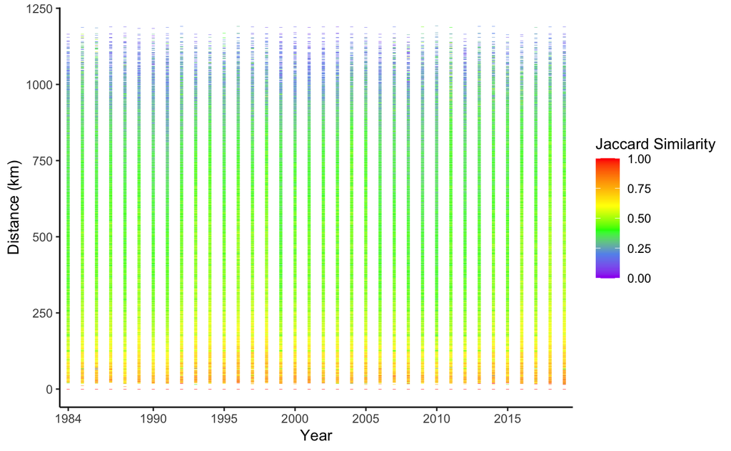

```r
#convert year to factor
setkey(ebs_distances_dissimilarities_allyears,year)
ebs_distances_dissimilarities_allyears[,year.f := as.factor(year)]

#jaccard similarity
(ebs_jaccard_heatmap <- ggplot(ebs_distances_dissimilarities_allyears_jaccard_rounded_allcombos,aes(as.factor(year),distance_km_1s, color = jaccard_similarity_mean_1s)) +
  geom_point(shape = 95, size = 1) +
  scale_color_gradientn(colors =
c("purple" ,"cornflowerblue", "green" , "yellow" ,"orange", "red")
  ) +
scale_x_discrete(limits=levels(ebs_distances_dissimilarities_allyears_jaccard_rounded_allcombos$year.f), breaks = c("1984", "1990", "1995", "2000", "2005", "2010","2015")) +
  labs(y = "Distance (km)", x = "Year", color = "Jaccard Similarity") +
  theme_classic())

ggsave(plot = ebs_jaccard_heatmap, path = here::here("figures","ebs"),file = "ebs_jaccard_heatmap.jpg")
ggsave(plot = ebs_jaccard_heatmap, path = here::here("figures","ebs"),file = "ebs_jaccard_heatmap.eps")
```

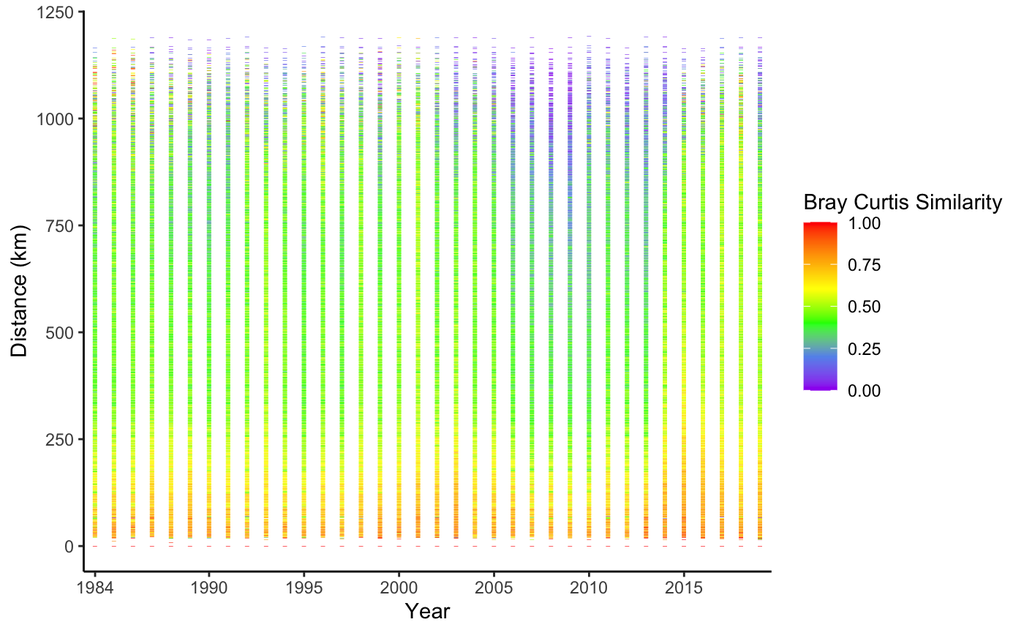

```r
#bray curtis similarity
(ebs_bray_heatmap <- ggplot(ebs_distances_dissimilarities_allyears_jaccard_rounded_allcombos,aes(as.factor(year),distance_km_1s, color = bray_similarity_mean_1s)) +
  geom_point(shape = 95, size = 1) +
  scale_color_gradientn(colors =
c("purple" ,"cornflowerblue", "green" , "yellow" ,"orange", "red")
  ) +
  scale_x_discrete(limits=levels(ebs_distances_dissimilarities_allyears_jaccard_rounded_allcombos$year.f), breaks = c("1984", "1990", "1995", "2000", "2005", "2010","2015")) +
  labs(y = "Distance (km)", x = "Year", color = "Bray Curtis Similarity") +
  theme_classic())

ggsave(plot = ebs_bray_heatmap, path = here::here("figures","ebs"),file = "ebs_bray_heatmap.jpg")
ggsave(plot = ebs_bray_heatmap, path = here::here("figures","ebs"),file = "ebs_bray_heatmap.eps")
```

Box plots

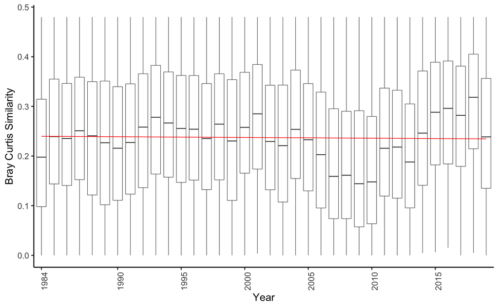

```r
#bray curtis similarity
(ebs_bray_boxplot <- ggplot(ebs_distances_dissimilarities_allyears,aes(year.f,bray_curtis_similarity_balanced)) +
  geom_boxplot(outlier.shape = NA, lwd = 0.2) +
  labs(x="Year", y = "Bray Curtis Similarity") +
  scale_x_discrete(limits=levels(ebs_distances_dissimilarities_allyears$year.f), breaks = c("1984", "1990", "1995", "2000", "2005", "2010","2015")) +
  geom_smooth(method = "lm", se=FALSE, color="red", aes(group=1), lwd = 0.3) +
  stat_regline_equation(label.x = 3, label.y = 32) +
    ylim(c(0,0.48)) +
  theme_classic() +
  theme(axis.text.x = element_text(angle = 90)))
```

[figure not shown]

```r
#bray curtis similarity
(ebs_bray_boxplot <- ggplot(ebs_distances_dissimilarities_allyears,aes(year.f,bray_curtis_similarity_balanced)) +
  geom_boxplot(outlier.shape = NA, lwd = 0.2) +
  labs(x="Year", y = "Bray Curtis Similarity") +
  scale_x_discrete(limits=levels(ebs_distances_dissimilarities_allyears$year.f), breaks = c("1984", "1990", "1995", "2000", "2005", "2010","2015")) +
  geom_smooth(method = "lm", se=FALSE, color="red", aes(group=1), lwd = 0.3) +
  stat_regline_equation(label.x = 3, label.y = 32) +
    ylim(c(0,0.48)) +
  theme_classic() +
  theme(axis.text.x = element_text(angle = 90)))
```

```r
#corresponding models
ebs_avg_jaccard_mod <- lm(data = ebs_distances_dissimilarities_allyears, formula = jaccard_similarity_turnover ~ as.numeric(year))
ebs_avg_bray_curtis_mod <- lm(data = ebs_distances_dissimilarities_allyears, formula = bray_curtis_similarity_balanced ~ as.numeric(year))
summary(ebs_avg_jaccard_mod)
```

```
Call:
lm(formula = jaccard_similarity_turnover ~ as.numeric(year),
    data = ebs_distances_dissimilarities_allyears)

Residuals:
     Min       1Q   Median       3Q      Max
-0.49331 -0.15776 -0.02604  0.14527  0.51374

Coefficients:
                  Estimate Std. Error t value Pr(>|t|)
(Intercept)      8.622e-02  3.245e-02   2.657  0.00788 **
as.numeric(year) 2.016e-04  1.621e-05  12.437  < 2e-16 ***
---
Signif. codes:  0 ‘***’ 0.001 ‘**’ 0.01 ‘*’ 0.05 ‘.’ 0.1 ‘ ’ 1

Residual standard error: 0.2189 on 1693846 degrees of freedom
Multiple R-squared:  9.131e-05, Adjusted R-squared:  9.072e-05
F-statistic: 154.7 on 1 and 1693846 DF,  p-value: < 2.2e-16
```

```r
summary(ebs_avg_jaccard_mod)
```

```
Call:
lm(formula = jaccard_similarity_turnover ~ as.numeric(year),
    data = ebs_distances_dissimilarities_allyears)

Residuals:
     Min       1Q   Median       3Q      Max
-0.49331 -0.15776 -0.02604  0.14527  0.51374

Coefficients:
                  Estimate Std. Error t value Pr(>|t|)
(Intercept)      8.622e-02  3.245e-02   2.657  0.00788 **
as.numeric(year) 2.016e-04  1.621e-05  12.437  < 2e-16 ***
---
Signif. codes:  0 ‘***’ 0.001 ‘**’ 0.01 ‘*’ 0.05 ‘.’ 0.1 ‘ ’ 1

Residual standard error: 0.2189 on 1693846 degrees of freedom
Multiple R-squared:  9.131e-05, Adjusted R-squared:  9.072e-05
F-statistic: 154.7 on 1 and 1693846 DF,  p-value: < 2.2e-16
```

```r
summary(ebs_avg_bray_curtis_mod)
```

```
Call:
lm(formula = bray_curtis_similarity_balanced ~ as.numeric(year),
    data = ebs_distances_dissimilarities_allyears)

Residuals:
     Min       1Q   Median       3Q      Max
-0.52638 -0.26444  0.00294  0.26592  0.50047

Coefficients:
                   Estimate Std. Error t value Pr(>|t|)
(Intercept)      -1.022e+00  4.379e-02  -23.35   <2e-16 ***
as.numeric(year)  7.671e-04  2.188e-05   35.06   <2e-16 ***
---
Signif. codes:  0 ‘***’ 0.001 ‘**’ 0.01 ‘*’ 0.05 ‘.’ 0.1 ‘ ’ 1

Residual standard error: 0.2953 on 1693846 degrees of freedom
Multiple R-squared:  0.0007253, Adjusted R-squared:  0.0007247
F-statistic:  1229 on 1 and 1693846 DF,  p-value: < 2.2e-16
```

```r
#pull out legend
ebs_legend_heatmaps <- get_legend(ebs_jaccard_heatmap + labs(color = "Similarity"))

ebs_merge <- plot_grid(ebs_jaccard_heatmap + theme(legend.position = "none", axis.title.x = element_blank(), axis.text.x = element_blank()) ,
                       ebs_bray_heatmap + theme(legend.position = "none", axis.title.x = element_blank(), axis.text.x = element_blank(), axis.title.y = element_blank()),
                    #   ebs_legend_heatmaps,
                       ebs_jaccard_boxplot, ebs_bray_boxplot,  nrow = 2, ncol = 2, align = "hv", axis = "lb")
ebs_merge
```

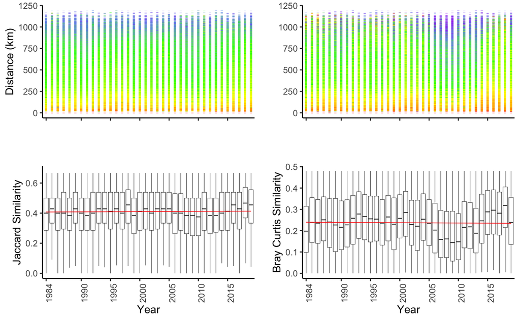

```r
ggsave(ebs_merge, path = here::here("figures","ebs"), file = "ebs_heat_boxplot_merge.jpg", width = 6, height = 5, unit = "in")
ggsave(ebs_merge, path = here::here("figures","ebs"), file = "ebs_heat_boxplot_merge.eps", width = 6, height = 5, unit = "in")
```

Add extra columns with coefficients

```r
ebs_stats[,jac_coef :=
           ebs_avg_jaccard_mod$coefficients[[2]]][, jac_p :=
          summary(ebs_avg_jaccard_mod)$coefficients[2,4]][,bray_coef :=
          ebs_avg_bray_curtis_mod$coefficients[[2]]][,bray.p :=
          summary(ebs_avg_bray_curtis_mod)$coefficients[2,4]]


saveRDS(ebs_stats, here::here("output","region_stats","ebs_stats.rds"))
```

###maybe i’ll do this later? maybe not At its heart, this graphic is just a ggplot() with a geom_raster() layer. The complication is, geom_raster() requires equally spaced points in both the x- and y-direction. The rest of this post is about how to make that happen.

Linear Interpolation

I interpolate in the distance direction first, because I think this is the better assumption: as you go down further away, a reasonable way to estimate the similarity at a distance which you did not measure is to draw a straight line between the similarity at the distance that you did measure. (Not great, but sure)

```r
estimate_jac_sim_by_year <- function(target_year, target_distance) {
  data_for_year <- ebs_distances_dissimilarities_allyears[year == target_year]

  # approx() is one way to do a linear interpolation
  approx(data_for_year$distance, data_for_year$jaccard_similarity, xout = target_distance)$y
}

estimate_jac_sim_by_year(1990, c(0,3000,300000))
```

Expand data inputs

```r
temp_interp_depth <- data.table(expand.grid(
  # the same years as ebs spring
  year = ebs_years,
  # ddistances can now be any value
  distance = seq(0, max(ebs_distances_dissimilarities_allyears$distance), by = 10))
)

temp_interp_depth[,jaccard_similarity_modeled := estimate_jac_sim_by_year(year,distance), year]
```

Visualize

```r
ggplot(temp_interp_depth,aes(year,distance, color = jaccard_similarity_modeled)) +
  geom_point() +
   scale_colour_gradient2(
    midpoint = 0.5,
    high = scales::muted("red"),
    low = scales::muted("blue")
  )
```

```r
estimate_jac_sim_by_distance <- function(target_distance, target_year) {
  data_for_distance <- temp_interp_depth[distance == target_distance,]
    setkey(data_for_distance, year)
  approx(data_for_distance$year, data_for_distance$jaccard_similarity_modeled, xout = target_year)$y
}

estimate_jac_sim_by_distance(
  target_distance = 1000000,
  target_year = c(1990,1998,2000)
)
```

Expand year grid

```r
jac_sim_raster <- data.table(expand.grid(
  # dates can now be any value
  year = seq(min(ebs_years), max(ebs_years), by = 1),
  # depths must be the same as in temp_interp_depth
  distance = unique(temp_interp_depth$distance))
)

jac_sim_raster[,jaccard_similarity_modeled := estimate_jac_sim_by_distance(distance,year),by = distance]
```

```r
ggplot(jac_sim_raster, aes(year, distance, fill = jaccard_similarity_modeled)) +
  geom_raster() +
  scale_fill_gradientn(colors =
c("purple" ,"blue"  , "green" , "yellow" ,"orange", "red")
  ) +
  coord_cartesian(expand = FALSE)
```